# Time series decomposition

## Transformations and adjustments

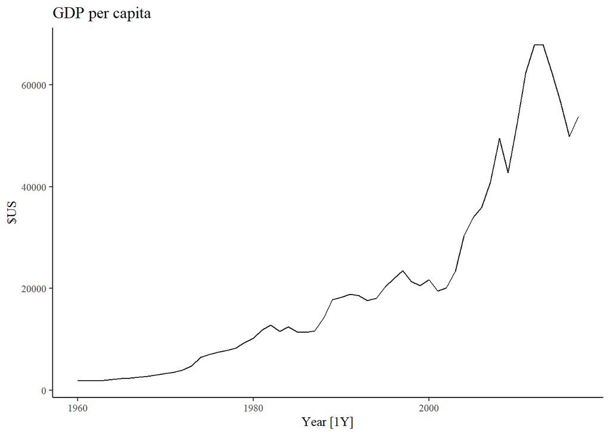

```r
global_economy %>%
  filter(Country == "Australia") %>%
  autoplot(GDP / Population) +
  labs(title = "GDP per capita", y = "$US")
```

```r
print_retail <- aus_retail %>%
  filter(Industry == "Newspaper and book retailing") %>%
  group_by(Industry) %>%
  index_by(Year = year(Month)) %>%
  summarise(Turnover = sum(Turnover))
aus_economy <- global_economy %>%
  filter(Code == "AUS")
```

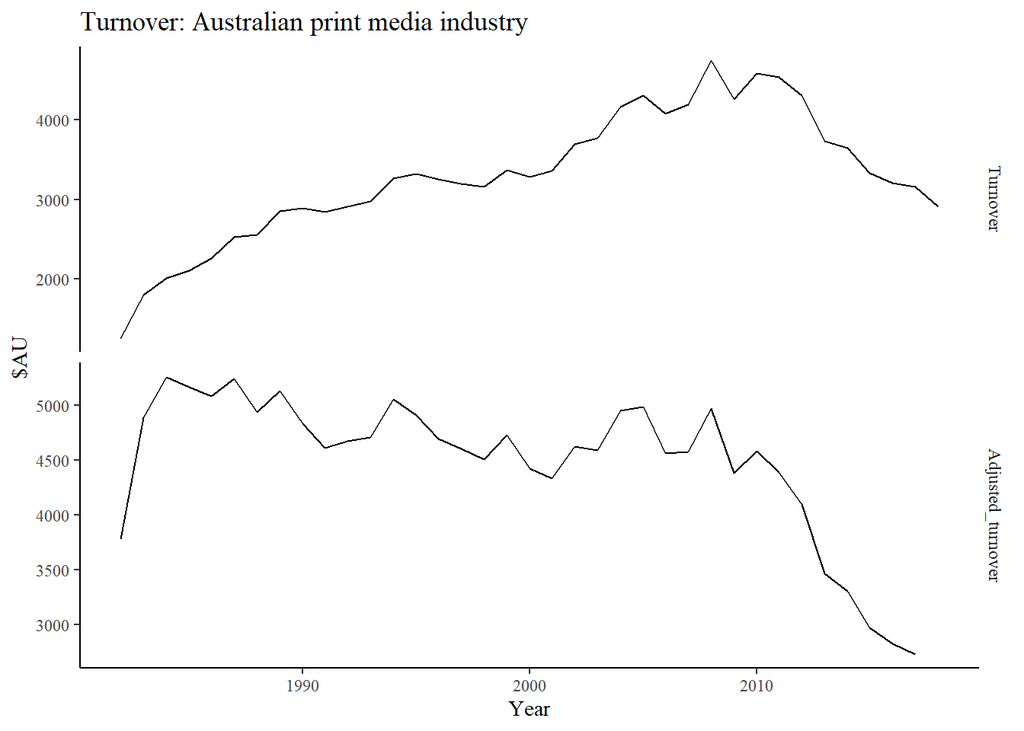

```r
print_retail %>%
  left_join(aus_economy, by = "Year") %>%
  mutate(Adjusted_turnover = Turnover / CPI * 100) %>%
  pivot_longer(c(Turnover, Adjusted_turnover),
               values_to = "Turnover") %>%
  mutate(name = factor(name,
         levels = c("Turnover", "Adjusted_turnover"))) %>%
  ggplot(aes(x = Year, y = Turnover)) +
  geom_line() +
  facet_grid(name ~ ., scales = "free_y") +
  labs(title = "Turnover: Australian print media industry",
       y = "$AU")
```

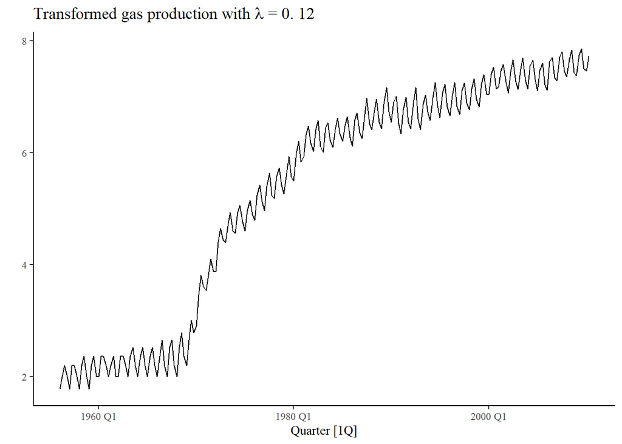

```r
lambda <- aus_production %>%
  features(Gas, features = guerrero) %>%
  pull(lambda_guerrero)
aus_production %>%
  autoplot(box_cox(Gas, lambda)) +
  labs(y = "",
       title = latex2exp::TeX(paste0(
         "Transformed gas production with $\\lambda$ = ",
         round(lambda, 2))))
```

## Time series components

```r
us_employment
```

```
## # A tsibble: 143,412 x 4 [1M]
## # Key:       Series_ID [148]
##       Month Series_ID     Title         Employed
##       <mth> <chr>         <chr>            <dbl>
##  1 1939 Jan CEU0500000001 Total Private    25338
##  2 1939 Feb CEU0500000001 Total Private    25447
##  3 1939 Mar CEU0500000001 Total Private    25833
##  4 1939 Apr CEU0500000001 Total Private    25801
##  5 1939 May CEU0500000001 Total Private    26113
##  6 1939 Jun CEU0500000001 Total Private    26485
##  7 1939 Jul CEU0500000001 Total Private    26481
##  8 1939 Aug CEU0500000001 Total Private    26848
##  9 1939 Sep CEU0500000001 Total Private    27468
## 10 1939 Oct CEU0500000001 Total Private    27830
## # ... with 143,402 more rows
```

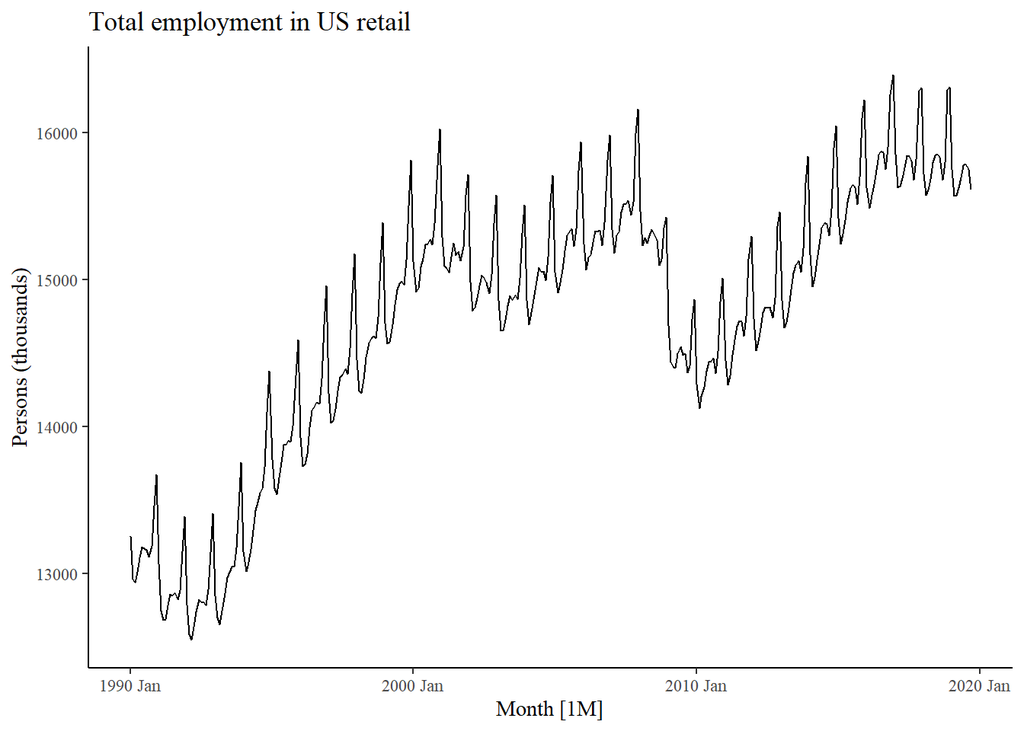

```r
us_retail_employment <- fpp3::us_employment %>%
  filter(year(Month) >= 1990, Title == "Retail Trade") %>%
  select(-Series_ID)
autoplot(us_retail_employment, Employed) +
  labs(y = "Persons (thousands)",
       title = "Total employment in US retail")
```

```r
dcmp <- us_retail_employment %>%
  model(stl = STL(Employed))
components(dcmp)
```

```
## # A dable: 357 x 7 [1M]
## # Key:     .model [1]
## # :        Employed = trend + season_year + remainder
##    .model    Month Employed  trend season_year remainder season_adjust
##    <chr>     <mth>    <dbl>  <dbl>       <dbl>     <dbl>         <dbl>
##  1 stl    1990 Jan   13256. 13288.      -33.0      0.836        13289.
##  2 stl    1990 Feb   12966. 13269.     -258.     -44.6          13224.
##  3 stl    1990 Mar   12938. 13250.     -290.     -22.1          13228.
##  4 stl    1990 Apr   13012. 13231.     -220.       1.05         13232.
##  5 stl    1990 May   13108. 13211.     -114.      11.3          13223.
##  6 stl    1990 Jun   13183. 13192.      -24.3     15.5          13207.
##  7 stl    1990 Jul   13170. 13172.      -23.2     21.6          13193.
##  8 stl    1990 Aug   13160. 13151.       -9.52    17.8          13169.
##  9 stl    1990 Sep   13113. 13131.      -39.5     22.0          13153.
## 10 stl    1990 Oct   13185. 13110.       61.6     13.2          13124.
## # ... with 347 more rows
```

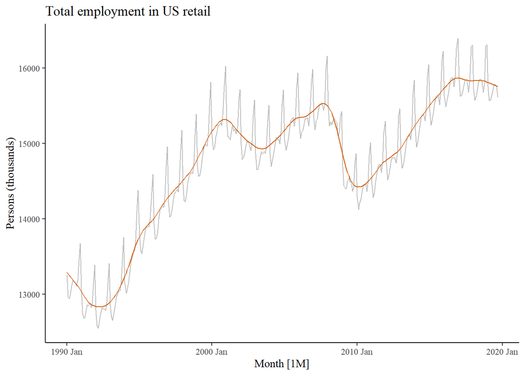

```r
components(dcmp) %>%
  as_tsibble() %>%
  autoplot(Employed, colour = "gray") +
  geom_line(aes(y = trend), colour = "#D55E00") +
  labs(
    y = "Persons (thousands)",
    title = "Total employment in US retail"
  )
```

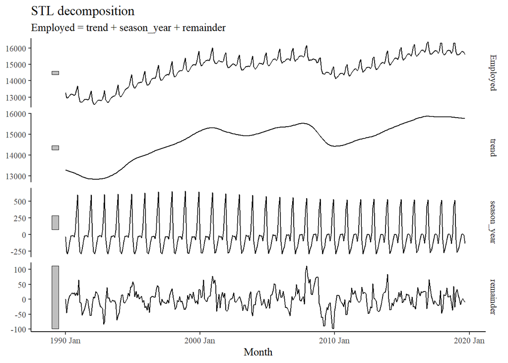

```r
components(dcmp) %>% autoplot()
```

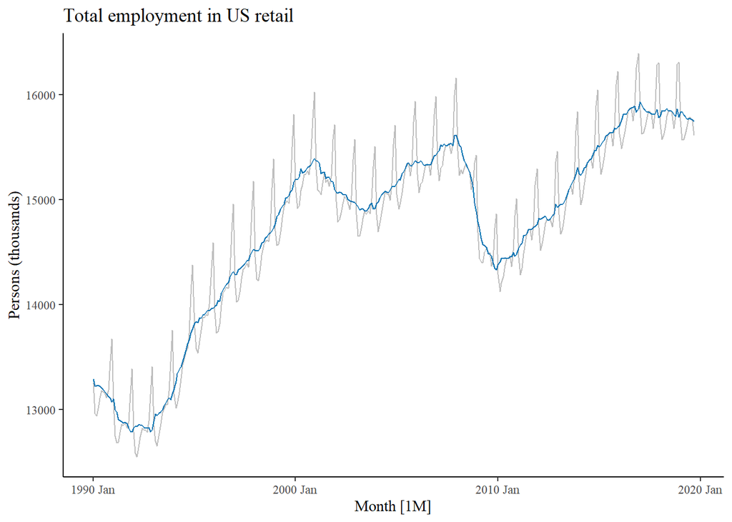

```r
components(dcmp) %>%
  as_tsibble() %>%
  autoplot(Employed, colour = "gray") +
  geom_line(aes(y = season_adjust), colour = "#0072B2") +
  labs(y = "Persons (thousands)",
       title = "Total employment in US retail")
```

## Moving averages

```r
global_economy
```

```
## # A tsibble: 15,150 x 9 [1Y]
## # Key:       Country [263]
##    Country     Code   Year         GDP Growth   CPI Imports Exports Population
##    <fct>       <fct> <dbl>       <dbl>  <dbl> <dbl>   <dbl>   <dbl>      <dbl>
##  1 Afghanistan AFG    1960  537777811.     NA    NA    7.02    4.13    8996351
##  2 Afghanistan AFG    1961  548888896.     NA    NA    8.10    4.45    9166764
##  3 Afghanistan AFG    1962  546666678.     NA    NA    9.35    4.88    9345868
##  4 Afghanistan AFG    1963  751111191.     NA    NA   16.9     9.17    9533954
##  5 Afghanistan AFG    1964  800000044.     NA    NA   18.1     8.89    9731361
##  6 Afghanistan AFG    1965 1006666638.     NA    NA   21.4    11.3     9938414
##  7 Afghanistan AFG    1966 1399999967.     NA    NA   18.6     8.57   10152331
##  8 Afghanistan AFG    1967 1673333418.     NA    NA   14.2     6.77   10372630
##  9 Afghanistan AFG    1968 1373333367.     NA    NA   15.2     8.90   10604346
## 10 Afghanistan AFG    1969 1408888922.     NA    NA   15.0    10.1    10854428
## # ... with 15,140 more rows
```

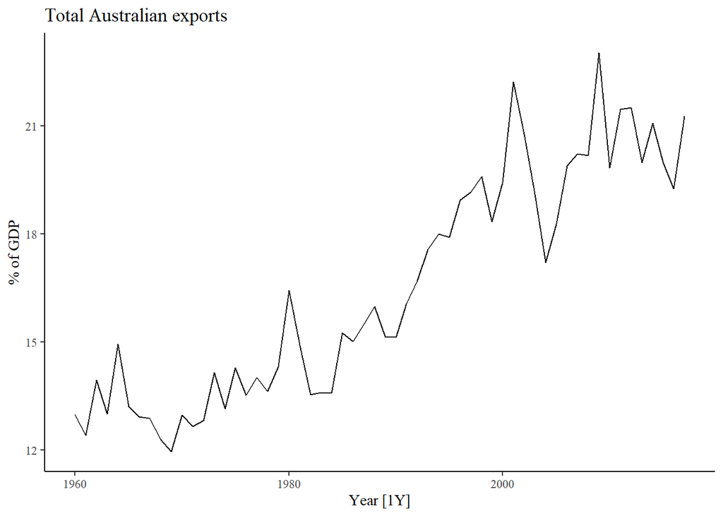

```r
global_economy %>%
  filter(Country == "Australia") %>%
  autoplot(Exports) +
  labs(y = "% of GDP", title = "Total Australian exports")
```

```r
aus_exports <- global_economy %>%
  filter(Country == "Australia") %>%
  mutate(
    `5-MA` = slider::slide_dbl(Exports, mean,
                .before = 2, .after = 2, .complete = TRUE)
  )
```

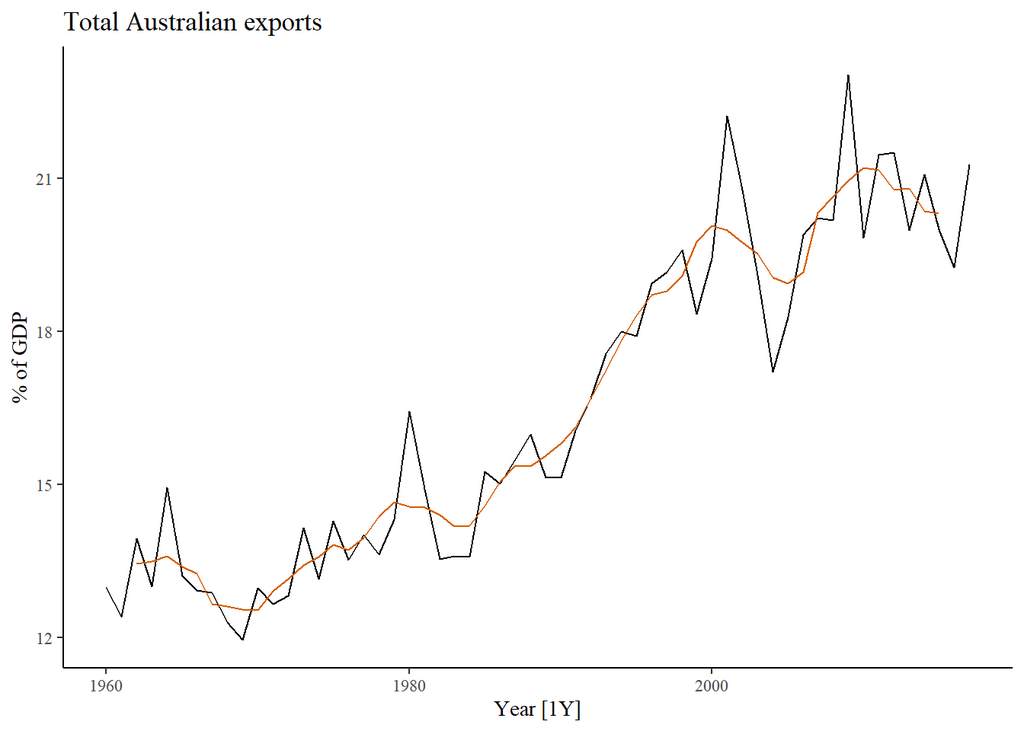

```r
aus_exports %>%
  autoplot(Exports) +
  geom_line(aes(y = `5-MA`), colour = "#D55E00") +
  labs(y = "% of GDP",
       title = "Total Australian exports") +
  guides(colour = guide_legend(title = "series"))
```

```r
beer <- aus_production %>%
  filter(year(Quarter) >= 1992) %>%
  select(Quarter, Beer)
beer_ma <- beer %>%
  mutate(
    `4-MA` = slider::slide_dbl(Beer, mean,
                .before = 1, .after = 2, .complete = TRUE),
    `2x4-MA` = slider::slide_dbl(`4-MA`, mean,
                .before = 1, .after = 0, .complete = TRUE)
  )
```

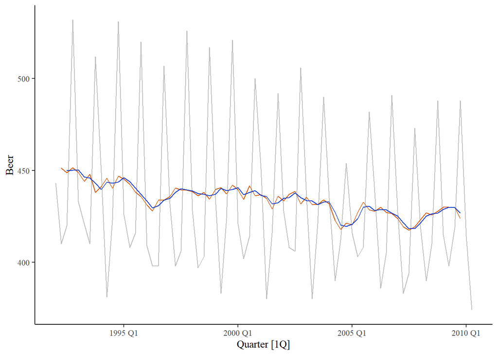

```r
beer_ma %>%
  autoplot(Beer, colour = "gray") +
  geom_line(aes(y = `4-MA`), colour = "#D55E00") +
  geom_line(aes(y = `2x4-MA`), colour = "#0039d5")
```

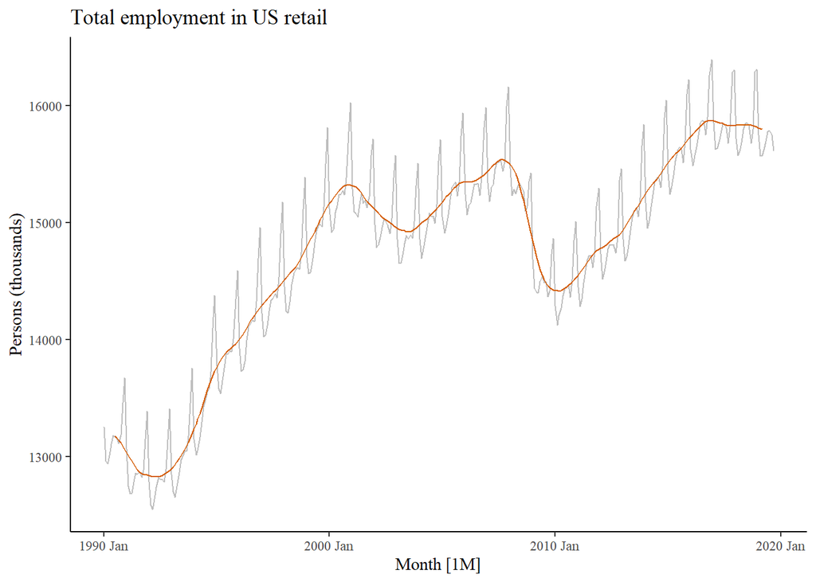

```r
us_retail_employment_ma <- us_retail_employment %>%
  mutate(
    `12-MA` = slider::slide_dbl(Employed, mean,
                .before = 5, .after = 6, .complete = TRUE),
    `2x12-MA` = slider::slide_dbl(`12-MA`, mean,
                .before = 1, .after = 0, .complete = TRUE)
  )
us_retail_employment_ma %>%
  autoplot(Employed, colour = "gray") +
  geom_line(aes(y = `2x12-MA`), colour = "#D55E00") +
  labs(y = "Persons (thousands)",
       title = "Total employment in US retail")
```

## Classical decomposition

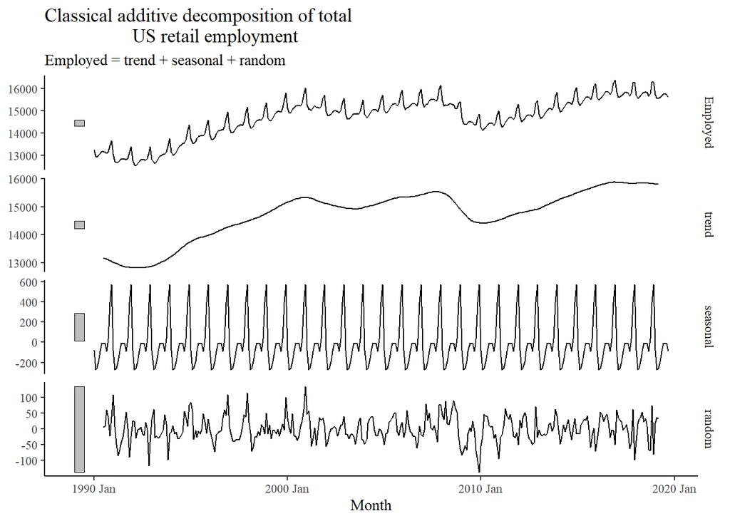

```r
us_retail_employment %>%
  model(
    classical_decomposition(Employed, type = "additive")
  ) %>%
  components() %>%
  autoplot() +
  labs(title = "Classical additive decomposition of total
                  US retail employment")
```

## Better methods

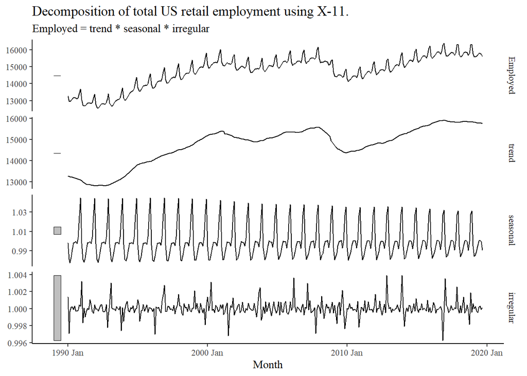

```r
x11_dcmp <- us_retail_employment %>%
  model(x11 = X_13ARIMA_SEATS(Employed ~ x11())) %>%
  components()
autoplot(x11_dcmp) +
  labs(title =
    "Decomposition of total US retail employment using X-11.")
```

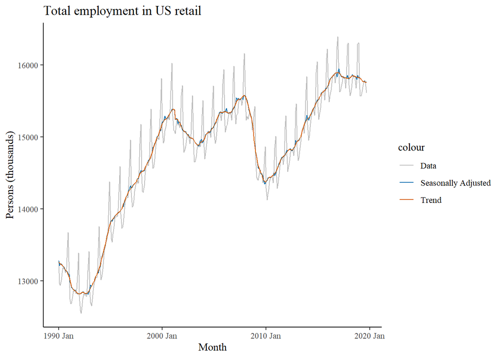

```r
x11_dcmp %>%
  ggplot(aes(x = Month)) +
  geom_line(aes(y = Employed, colour = "Data")) +
  geom_line(aes(y = season_adjust,
                colour = "Seasonally Adjusted")) +
  geom_line(aes(y = trend, colour = "Trend")) +
  labs(y = "Persons (thousands)",
       title = "Total employment in US retail") +
  scale_colour_manual(
    values = c("gray", "#0072B2", "#D55E00"),
    breaks = c("Data", "Seasonally Adjusted", "Trend")
  )
```

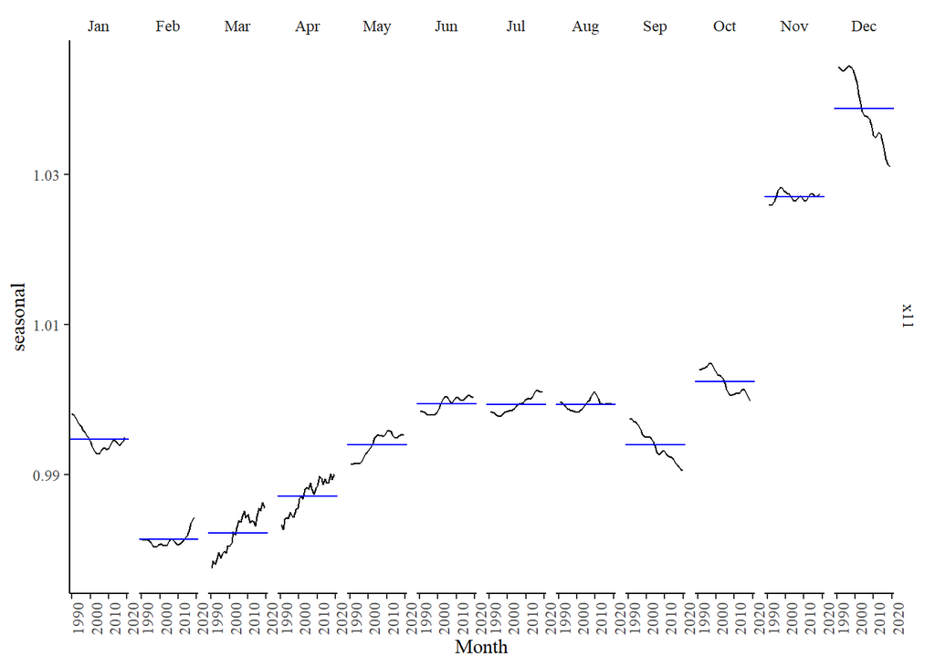

```r
x11_dcmp %>%
  gg_subseries(seasonal)
```

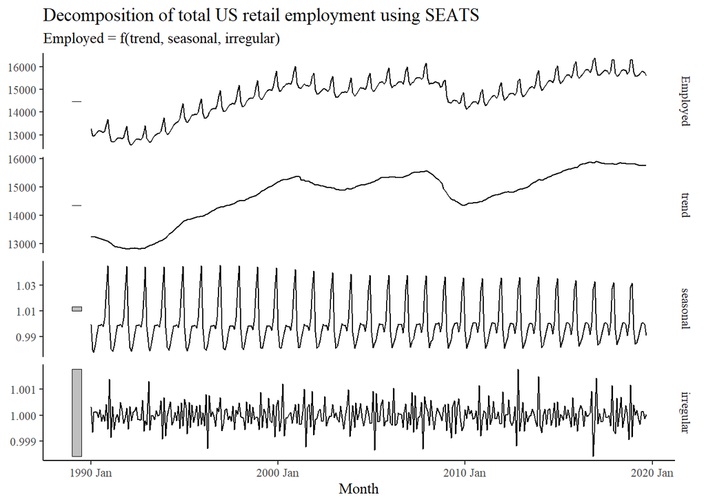

```r
seats_dcmp <- us_retail_employment %>%
  model(seats = X_13ARIMA_SEATS(Employed ~ seats())) %>%
  components()
autoplot(seats_dcmp) +
  labs(title =
    "Decomposition of total US retail employment using SEATS")
```

## STL decomposition

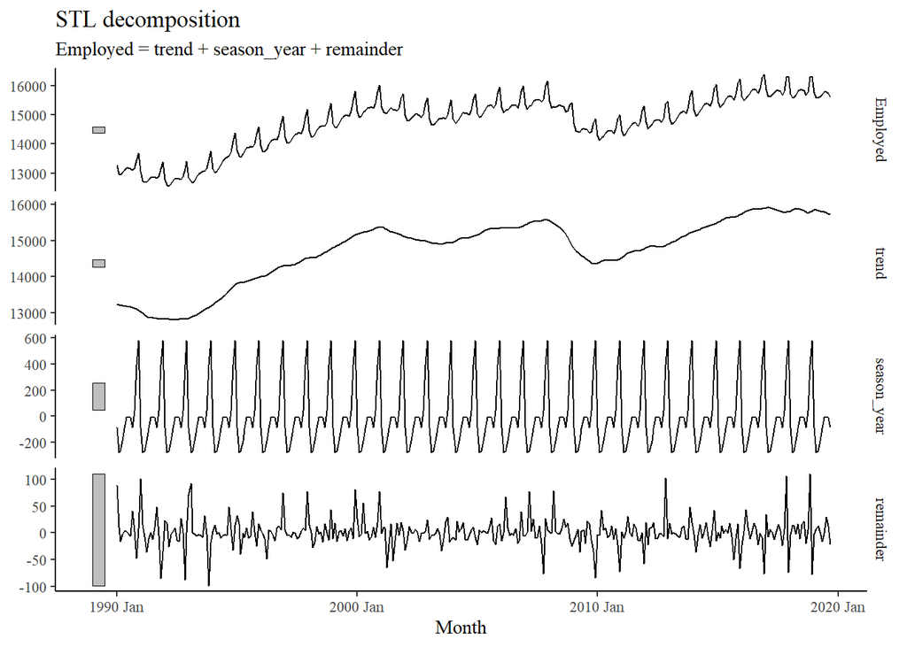

```r
us_retail_employment %>%
  model(
    STL(Employed ~ trend(window = 7) +
                   season(window = "periodic"),
    robust = TRUE)) %>%
  components() %>%
  autoplot()
```

## Exercises

1. Countries GDP

```r
excluded_groups <- c("World", "Arab World",
  "Central Europe and the Baltics", "Early-demographic dividend",
  "East Asia & Pacific", "East Asia & Pacific (excluding high income)",
  "East Asia & Pacific (IDA & IBRD countries)", "Euro area",
  "Europe & Central Asia", "Europe & Central Asia (excluding high income)",
  "Europe & Central Asia (IDA & IBRD countries)", "European Union",
  "Fragile and conflict affected situations",
  "Heavily indebted poor countries (HIPC)", "High income",
  "IBRD only", "IDA & IBRD total", "IDA blend", "IDA only",
  "IDA total", "Late-demographic dividend", "Latin America & Caribbean",
  "Latin America & Caribbean (excluding high income)",
  "Latin America & the Caribbean (IDA & IBRD countries)",
  "Least developed countries: UN classification",
  "Low & middle income", "Low income", "Lower middle income",
  "Middle East & North Africa", "Middle East & North Africa (excluding high income)",
  "Middle East & North Africa (IDA & IBRD countries)", "Middle income",
  "North America", "OECD members", "Other small states", "Pacific island small states",
  "Post-demographic dividend", "Pre-demographic dividend", "Small states",
  "South Africa", "South Asia", "South Asia (IDA & IBRD)",
  "Sub-Saharan Africa", "Sub-Saharan Africa (excluding high income)",
  "Upper middle income"
  )
```

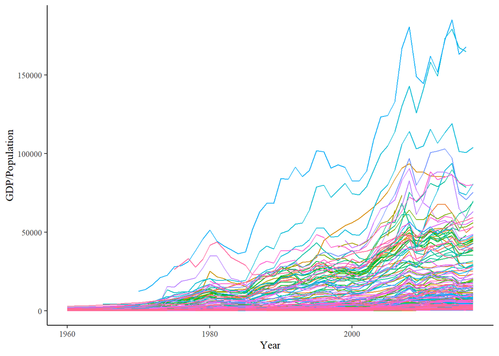

```r
global_economy %>%
  filter(!Country %in% excluded_groups) %>%
  ggplot(
    aes(x = Year, y = GDP / Population, color = Country)
  ) +
  geom_line() +
  theme(legend.position = "none")
```

```r
as_tibble(global_economy) %>%
  drop_na(GDP) %>%
  filter(!Country %in% excluded_groups) %>%
  mutate(gdp_capita = GDP / Population) %>%
  group_by(Year) %>%
  filter(gdp_capita == max(gdp_capita)) %>%
  select(Country, Year, gdp_capita) %>%
  arrange(Year) %>%
  rename(`GDP per capita` = gdp_capita) %>%
  kable()
```

| Country | Year | GDP per capita |
| --- | --- | --- |
| United States | 1960 | 3007.123 |
| United States | 1961 | 3066.563 |
| United States | 1962 | 3243.843 |
| United States | 1963 | 3374.515 |
| United States | 1964 | 3573.941 |
| Kuwait | 1965 | 4429.171 |
| Kuwait | 1966 | 4556.463 |
| United States | 1967 | 4336.427 |
| United States | 1968 | 4695.923 |
| United States | 1969 | 5032.145 |
| Monaco | 1970 | 12479.725 |
| Monaco | 1971 | 13813.301 |
| Monaco | 1972 | 16733.622 |
| Monaco | 1973 | 21422.841 |
| Monaco | 1974 | 22707.456 |
| Monaco | 1975 | 28254.276 |
| United Arab Emirates | 1976 | 29698.169 |
| United Arab Emirates | 1977 | 33245.836 |
| Monaco | 1978 | 38353.806 |
| Monaco | 1979 | 45838.162 |
| Monaco | 1980 | 51528.547 |
| Monaco | 1981 | 44366.295 |
| Monaco | 1982 | 41385.356 |
| Monaco | 1983 | 38887.766 |
| Monaco | 1984 | 36381.697 |
| Monaco | 1985 | 37553.358 |
| Monaco | 1986 | 52174.842 |
| Monaco | 1987 | 63043.178 |
| Monaco | 1988 | 68434.228 |
| Monaco | 1989 | 68576.585 |
| Monaco | 1990 | 84286.696 |
| Monaco | 1991 | 83732.701 |
| Monaco | 1995 | 101993.122 |
| Monaco | 1996 | 101328.795 |
| Monaco | 1997 | 90882.923 |
| Monaco | 1998 | 93093.260 |
| Monaco | 1999 | 91383.940 |
| Monaco | 2000 | 82534.874 |
| Monaco | 2001 | 82552.567 |
| Monaco | 2002 | 89061.051 |
| Monaco | 2003 | 108978.489 |
| Monaco | 2004 | 123382.016 |
| Monaco | 2005 | 124374.268 |
| Monaco | 2006 | 133195.429 |
| Monaco | 2007 | 167124.741 |
| Monaco | 2008 | 180640.125 |
| Monaco | 2009 | 149221.362 |
| Monaco | 2010 | 144569.176 |
| Monaco | 2011 | 162155.499 |
| Monaco | 2012 | 152000.362 |
| Liechtenstein | 2013 | 173528.150 |
| Monaco | 2014 | 185152.527 |
| Liechtenstein | 2015 | 167590.608 |
| Monaco | 2016 | 168010.915 |
| Luxembourg | 2017 | 104103.037 |

Highest GDP per capita: mostly very small (and rich) countries.

2. Transformations

Note: I’d be a bit [careful with transformations](https://stats.stackexchange.com/questions/18844/when-and-why-should-you-take-the-log-of-a-distribution-of-numbers). Maybe do this based on an analysis of residuals from a regression, in the future. Plus, these transformations won’t be as interpretable as logs.

Remember that the transformation is done to make the magnitude of the seasonal variation more uniform.

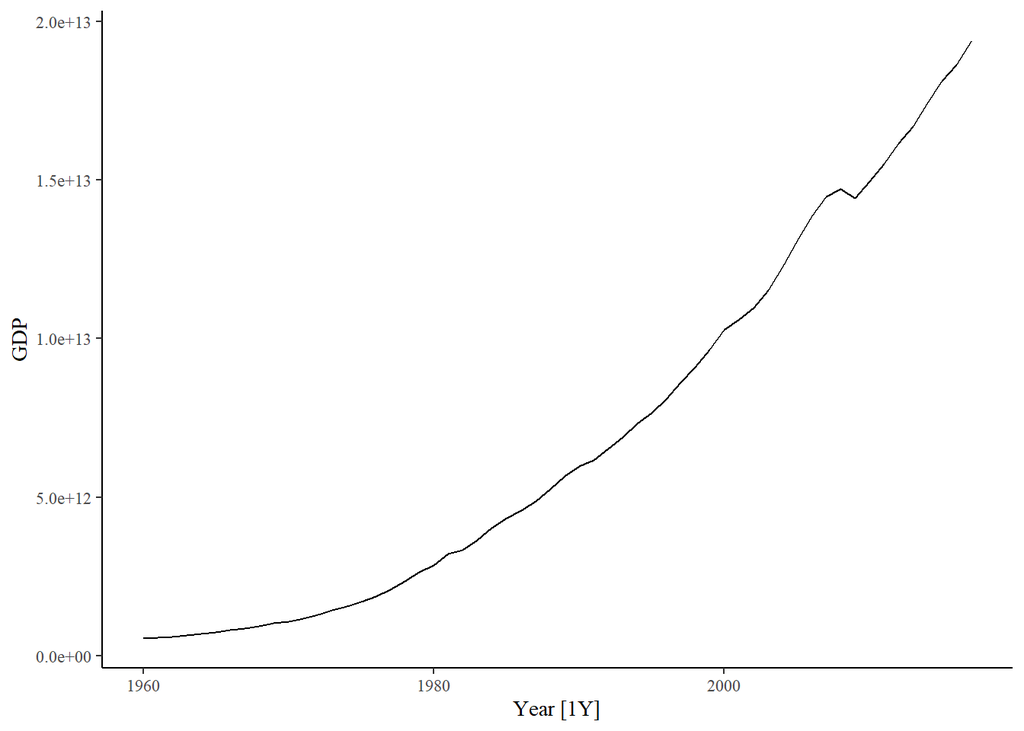

```r
global_economy %>%
  filter(Country == "United States") %>%
  autoplot(GDP)
```

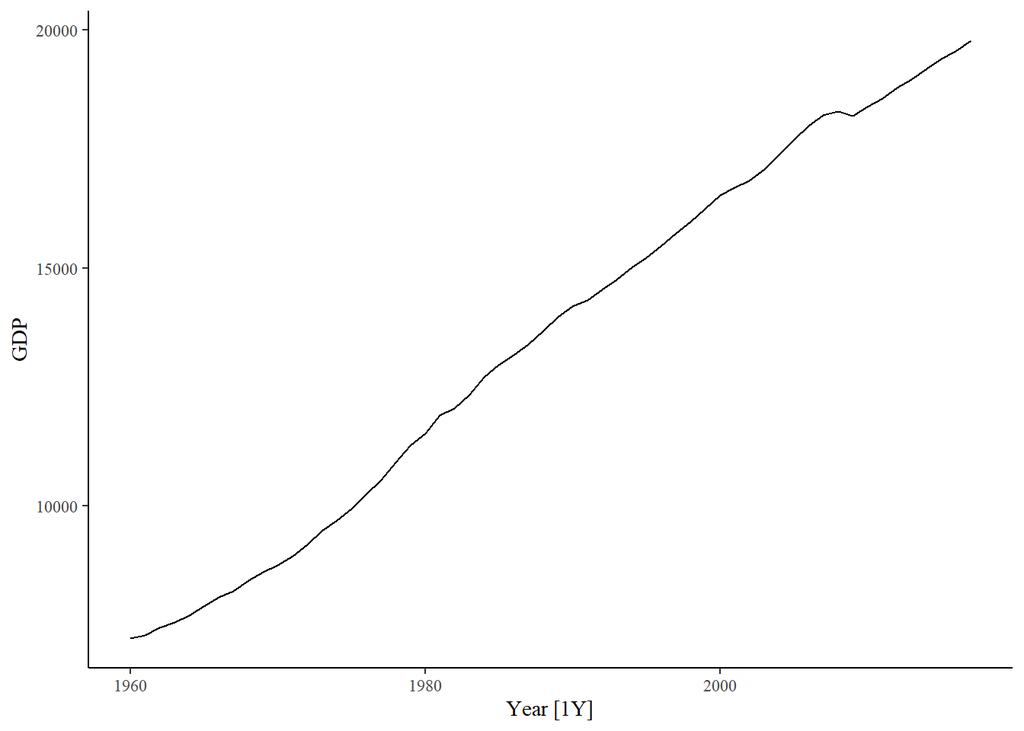

```r
global_economy %>%
  filter(Country == "United States") %>%
  mutate(
    GDP = box_cox(
      x = GDP,
      lambda = get_boxcox_lambda(., "GDP")
    )
  ) %>%
  autoplot(GDP)
```

We get a slightly more “linear” variable. I’d rather just take the log.

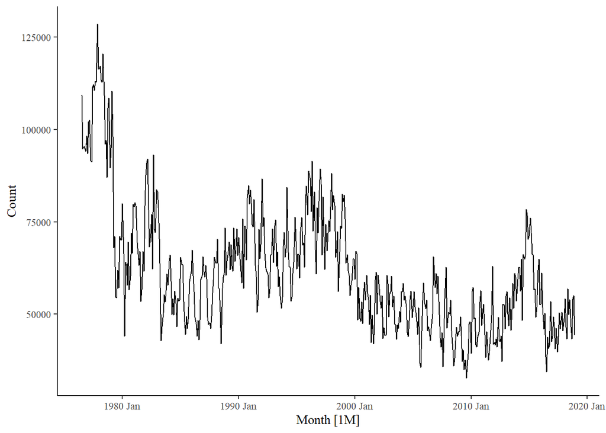

```r
aus_livestock %>%
  filter(Animal == "Bulls, bullocks and steers", State == "Victoria") %>%
  autoplot(Count)
```

Not sure a transformation will be useful here, but I may be wrong.

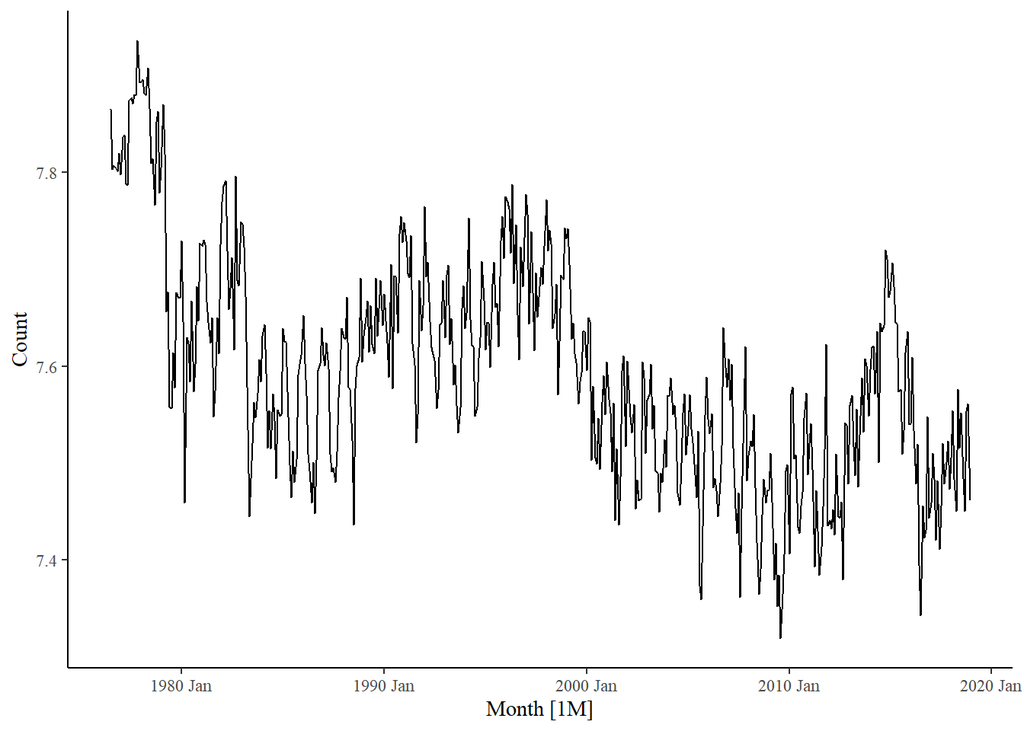

```r
aus_livestock %>%
  filter(Animal == "Bulls, bullocks and steers", State == "Victoria") %>%
  mutate(Count = box_cox(
    x = Count,
    lambda = get_boxcox_lambda(., "Count")
    )
  ) %>%
  autoplot(Count)
```

Probably useless here.

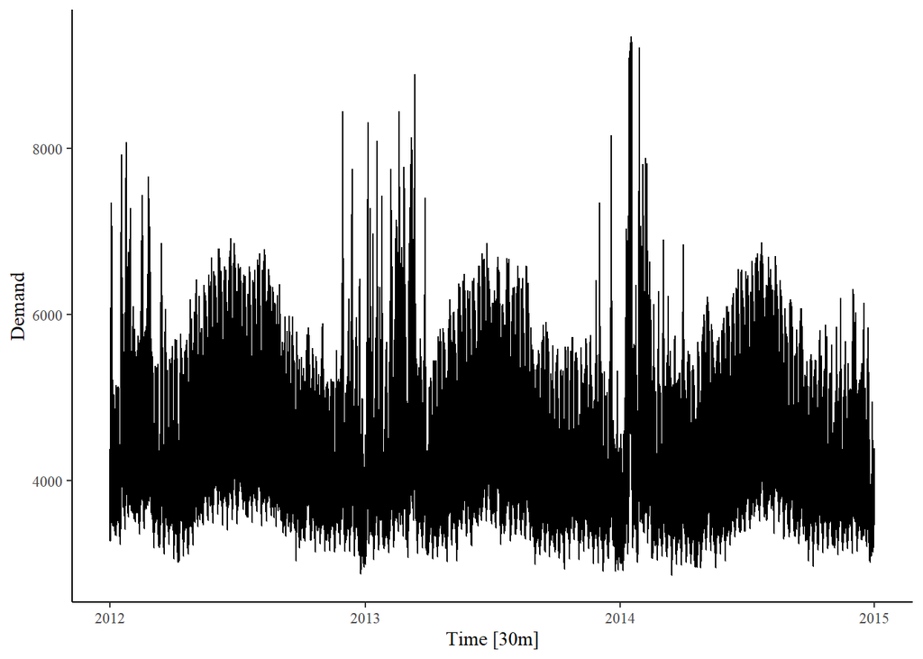

```r
vic_elec %>%
  autoplot(Demand)
```

No point in doing anything here. There does not seem to be any trend, and the variable is highly non-linear.

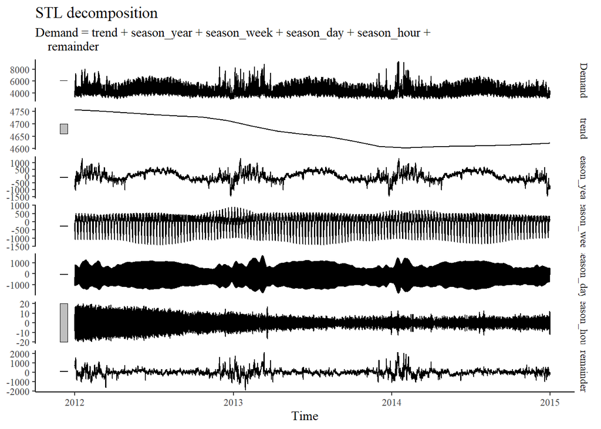

```r
vic_elec_stl <- vic_elec %>%
  model(stl = STL(Demand)) %>%
  components(stl)

vic_elec_stl %>%
  autoplot()
```

Quite complex.

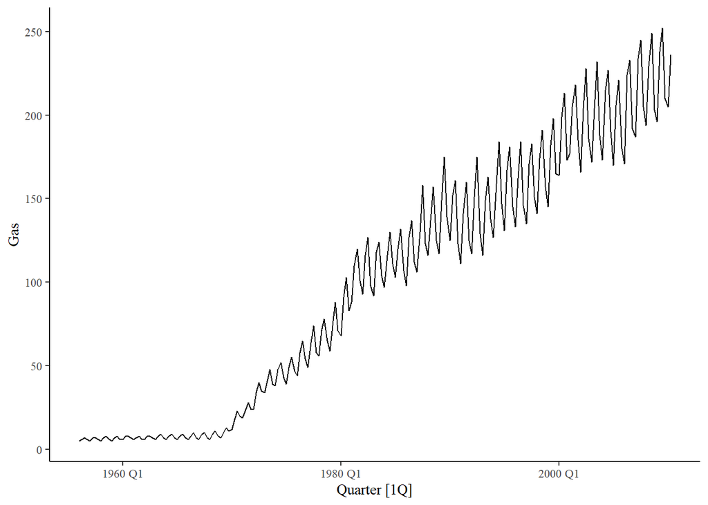

```r
aus_production %>%
  autoplot(Gas)
```

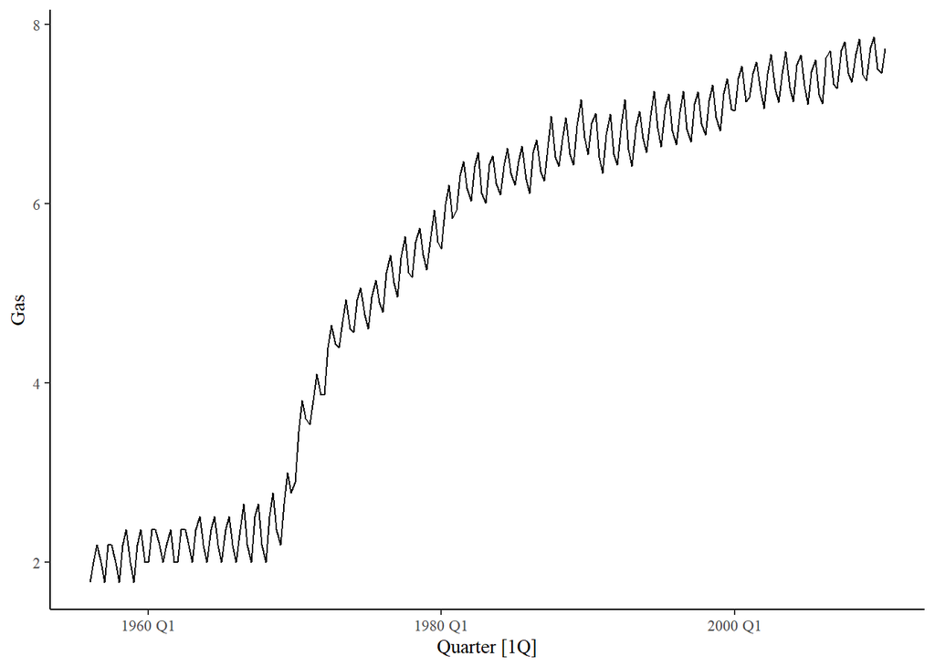

```r
aus_production %>%
  mutate(
    Gas = box_cox(
      x = Gas,
      lambda = get_boxcox_lambda(., "Gas")
    )
  ) %>%
  autoplot(Gas)
```

Not sure why the transformation does not help here.

4. Retail

```r
set.seed(451)
aus_retail_sample <- aus_retail %>%
  filter(`Series ID` == sample(aus_retail$`Series ID`, 1))
```

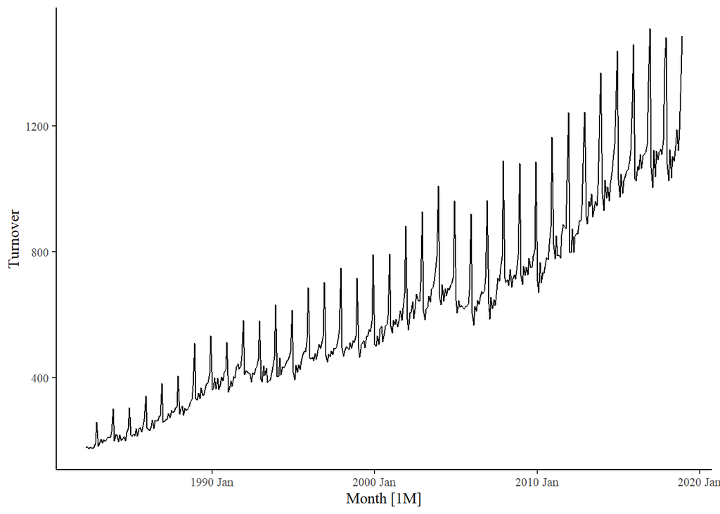

```r
aus_retail_sample %>%
  autoplot(Turnover)
```

Box-cox should be useful there.

```r
aus_retail_sample %>% get_boxcox_lambda(., "Turnover")
```

```
## [1] 0.003026741
```

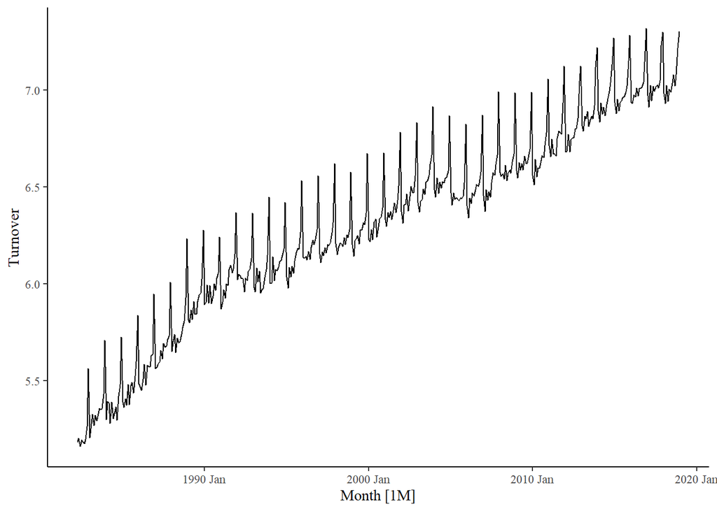

```r
aus_retail_sample %>%
  mutate(Turnover = log(Turnover)
  ) %>%
  autoplot(Turnover)
```

Lambda is nearly identical to 0. I took the log instead.

5. I’ll skip the Box-Cox transformations. I’ve done enough.
6. 3x5-MA = 7-MA with weights

5-MA:

$$MA_t = \frac{1}{5}(y_{t-2} + y_{t-1} + y_t + y_{t+1} + y_{t+2})$$

3x5-MA:

$$\frac{1}{3}(\frac{1}{5}MA_{t-1} + \frac{1}{5}MA_{t} + \frac{1}{5}MA_{t+1}) \\
= \frac{1}{15}MA_{t-1} + \frac{1}{15}MA_{t} + \frac{1}{15}MA_{t+1} \\
= \frac{1}{15}y_{t-3} + \frac{2}{15}y_{t-2} + \frac{3}{15}y_{t-1} + \frac{3}{15}y_t + \frac{3}{15}y_{t+1} + \frac{2}{15}y_{t+2} + \frac{1}{15}y_{t+3}$$

7. Some plots on aus_production

```r
gas <- tail(aus_production, 5*4) %>% dplyr::select(Gas)
```

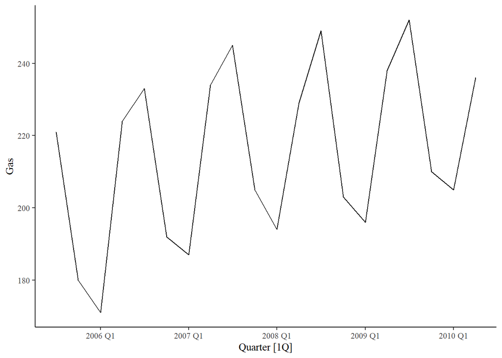

```r
gas %>% autoplot(Gas)
```

Increasing trend. Low output (or demand) in Q1 and Q4, high in Q2 & Q3.

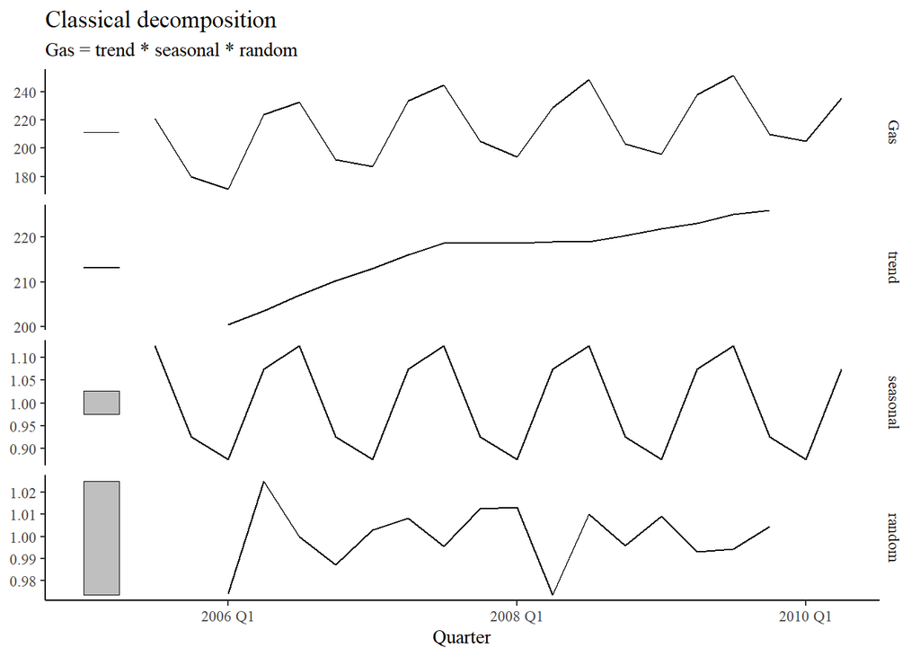

```r
gas %>%
  model(
    classical_decomposition(Gas, type = "multiplicative")
  ) %>%
  components %>%
  autoplot()
```

I was right.

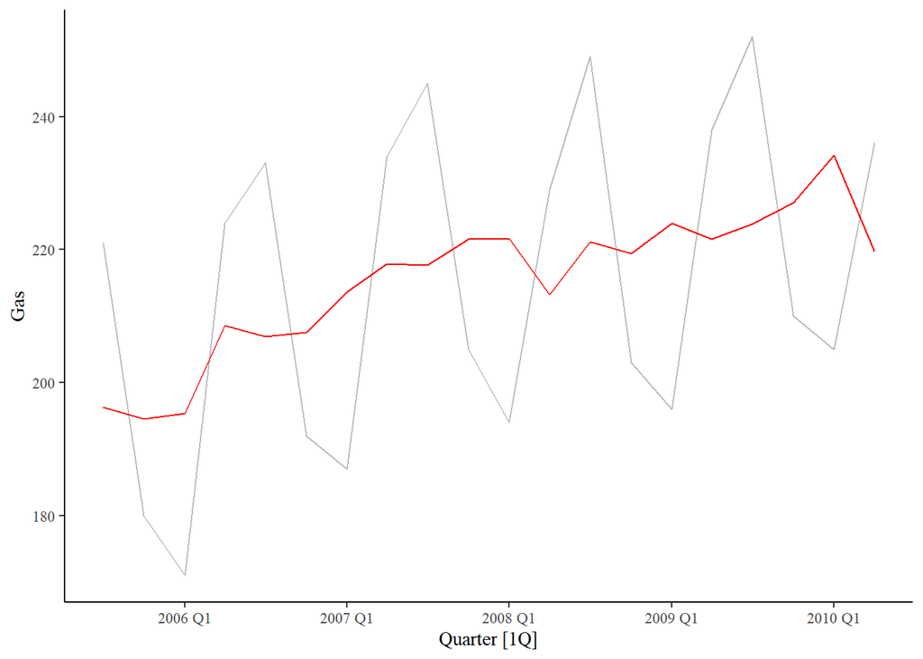

```r
gas %>%
  model(
    classical_decomposition(Gas, type = "multiplicative")
  ) %>%
  components %>%
  select(Quarter, Gas, season_adjust) %>%
  autoplot(Gas, colour = "gray") +
  geom_line(aes(y=season_adjust), colour = "red")
```

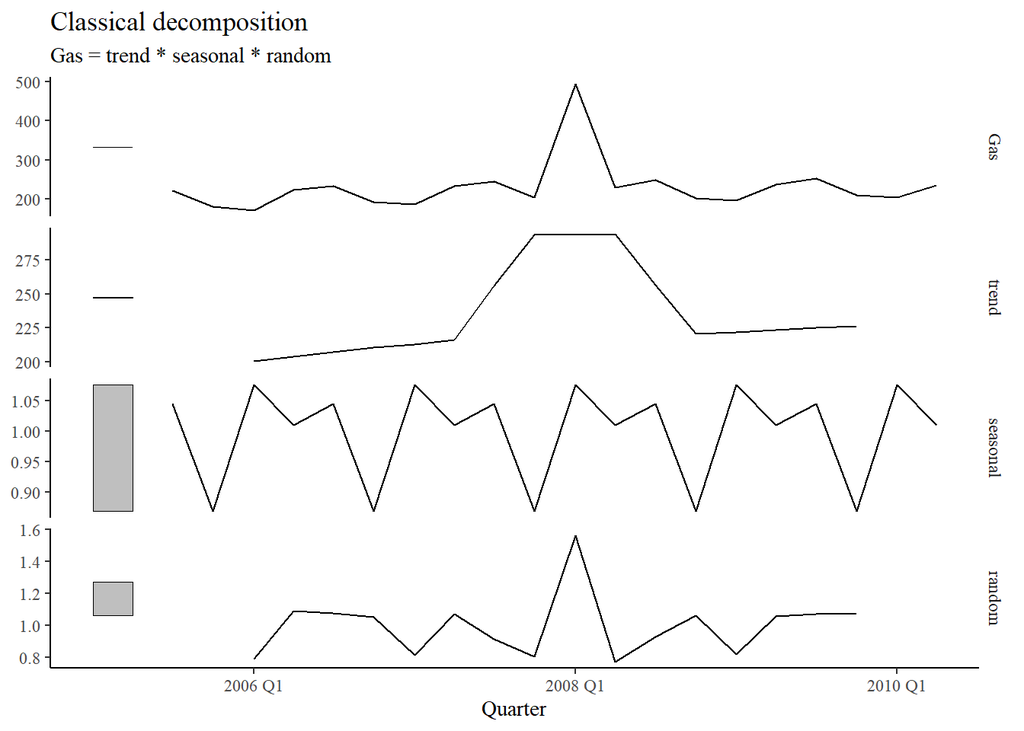

```r
gas %>%
  mutate(
    Quarter_char = Quarter %>% as.character(),
    Gas = replace(
      Gas,
      Quarter_char == "2008 Q1",
      Gas[Quarter_char == "2008 Q1"] + 300
    )
  ) %>%
  model(
    classical_decomposition(Gas, type = "multiplicative")
  ) %>%
  components %>%
  autoplot()
```

An outlier does mess things up. Since the outlier is in Q1, now the seasonal demand in Q1 is very high. Plus, the outlier is seen in the trend, and in the random component.

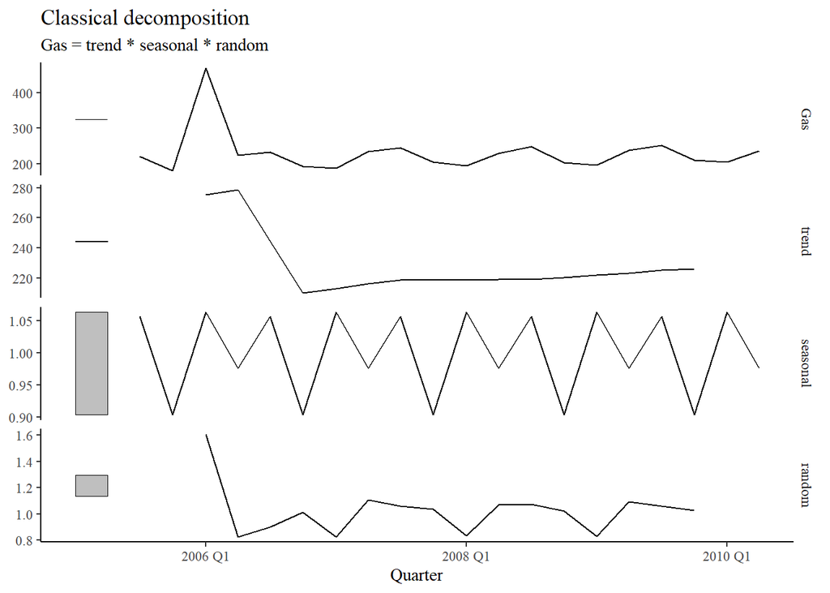

```r
gas %>%
  mutate(
    Quarter_char = Quarter %>% as.character(),
    Gas = replace(
      Gas,
      Quarter_char == "2006 Q1",
      Gas[Quarter_char == "2006 Q1"] + 300
    )
  ) %>%
  model(
    classical_decomposition(Gas, type = "multiplicative")
  ) %>%
  components %>%
  autoplot()
```

Still problematic. But it doesn’t seem to change much, compared to an outlier in the middle in of time series.

8. X-11 on retail data

```
## Plot variable not specified, automatically selected `.vars = Turnover`
```

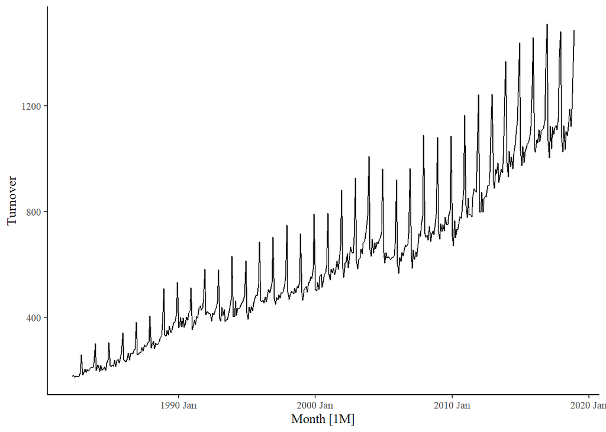

```r
aus_retail_sample %>%
  autoplot()
```

No transformation

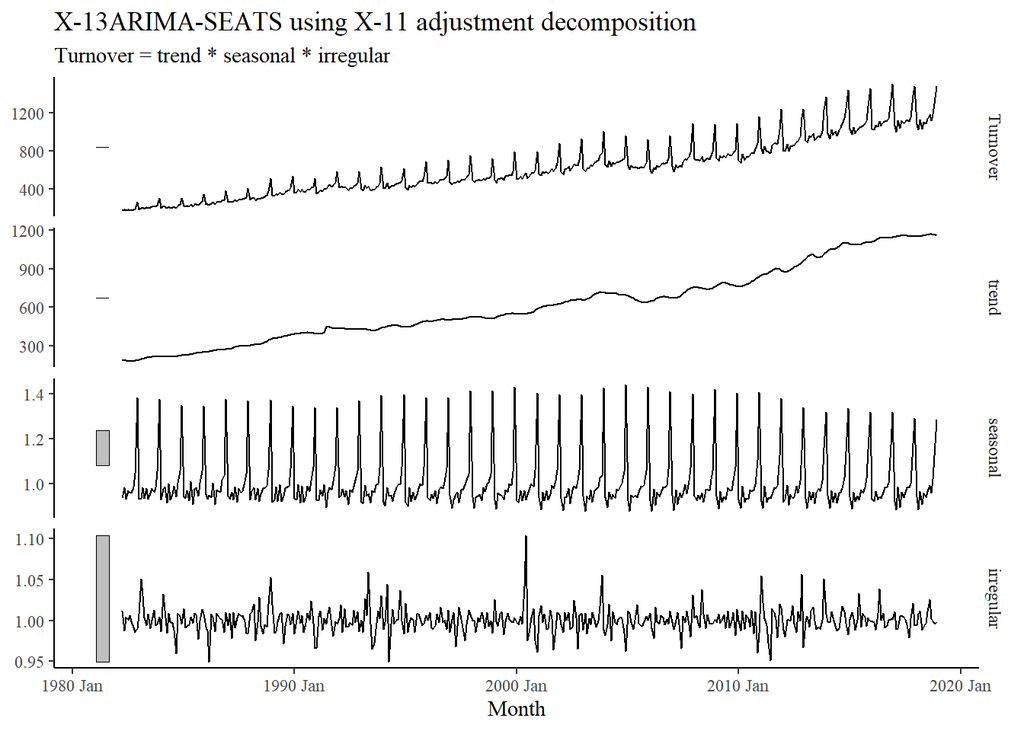

```r
aus_retail_sample %>%
  model(
    x11 = X_13ARIMA_SEATS(Turnover ~ x11())
  ) %>%
  components %>%
  autoplot()
```

Log transformed

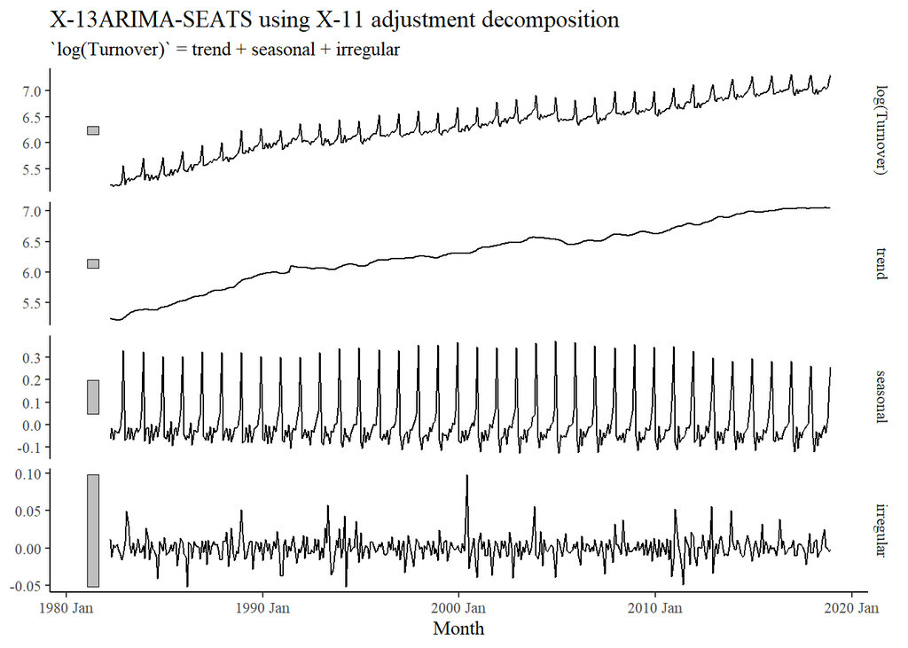

```r
aus_retail_sample %>%
  model(
    x11 = X_13ARIMA_SEATS(log(Turnover) ~ x11())
  ) %>%
  components %>%
  autoplot()
```

There doesn’t seem to be anything weird. Except some irregularity in the remainder plot, on the beginning of the 2000s. But nothing out of the ordinary.

9. Skipped. Just describing graphs.
10. Canadian gas

```
## Plot variable not specified, automatically selected `.vars = Volume`
```

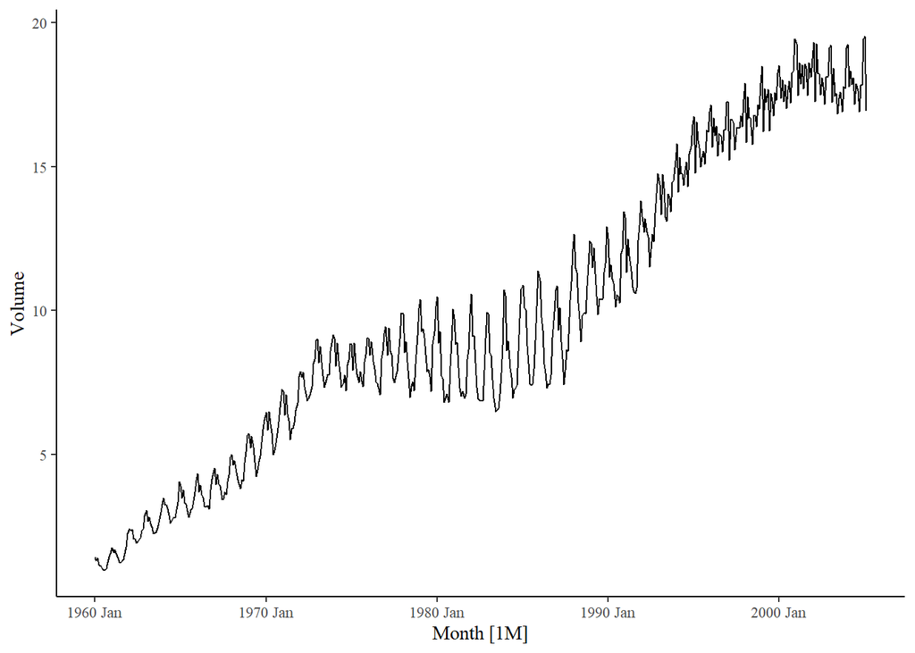

```r
canadian_gas %>%
  autoplot()
```

```r
canadian_gas %>%
  gg_season()
```

```
## Plot variable not specified, automatically selected `y = Volume`
```

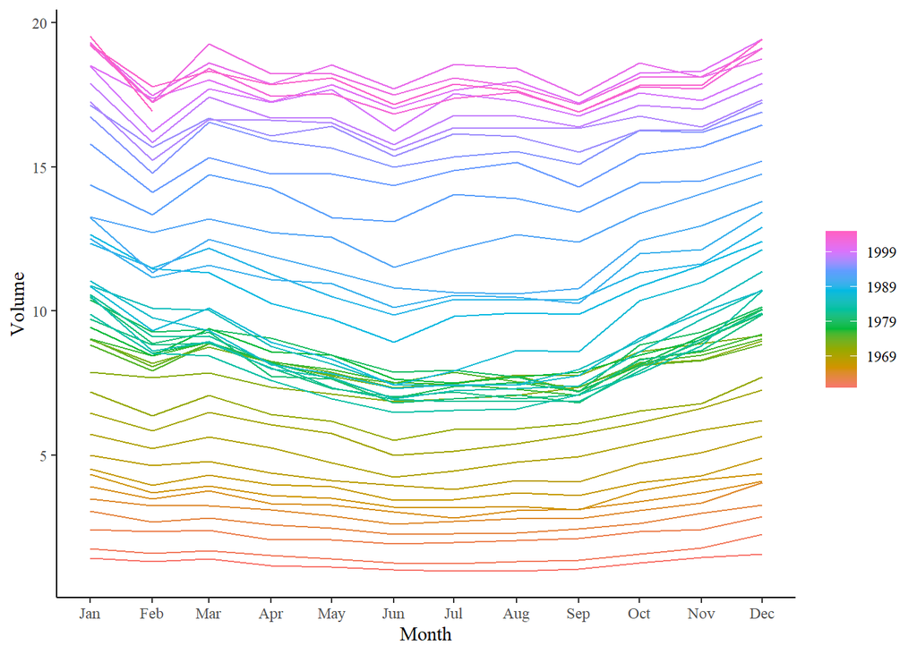

Indeed: low seasonality in the 60s, quite higher in the mid-70S to 80s. There is still a bit of seasonality after that.

```r
canadian_gas %>%
  gg_subseries()
```

```
## Plot variable not specified, automatically selected `y = Volume`
```

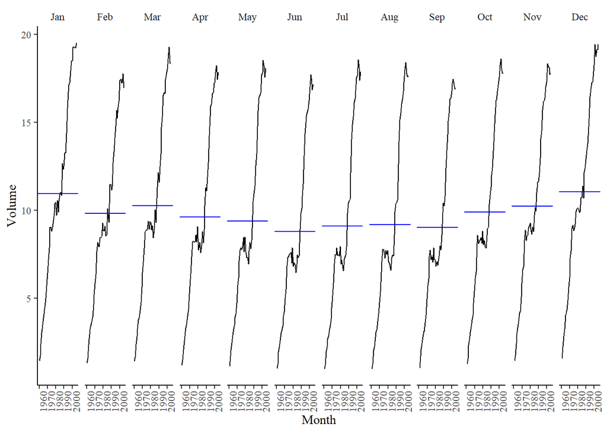

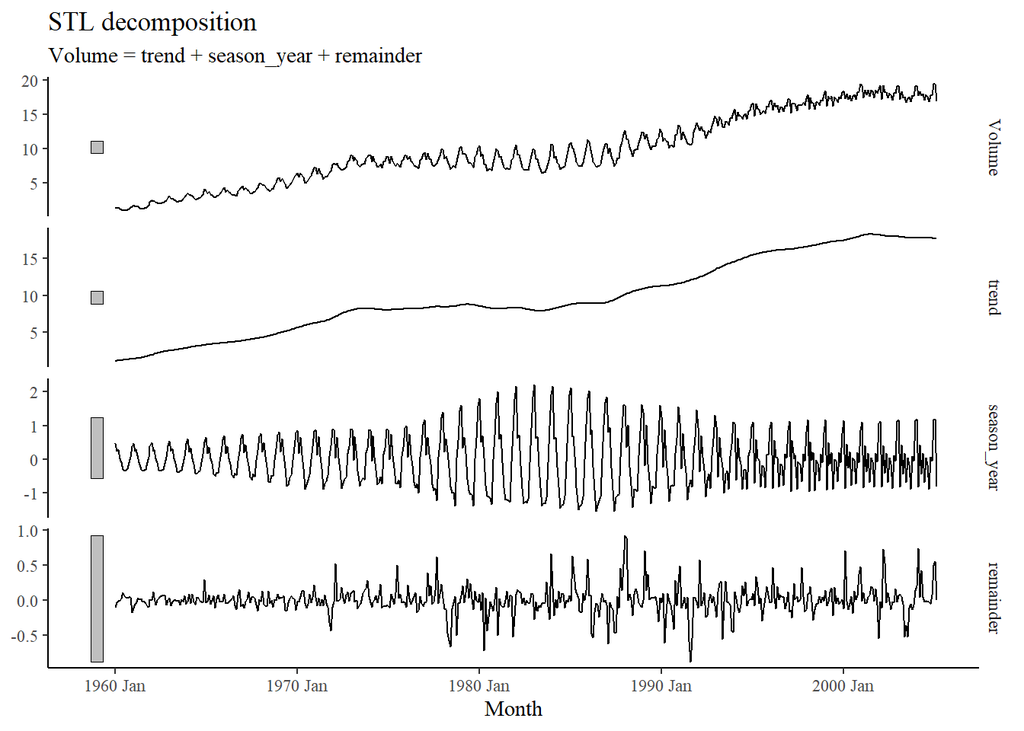

```r
canadian_gas %>%
  model(
    STL(Volume ~ trend(window = 18) +
                   season(window = 6),
    robust = TRUE)) %>%
  components() %>%
  autoplot()
```

Maybe there is a metric or some indicator to correctly choose the time window. A 6-month window allows us to see the evolution of seasonality over the years quite nicely.

```r
canadian_gas %>%
  model(
    STL(Volume ~ trend(window = 18) +
                   season(window = 6),
    robust = TRUE)) %>%
  components() %>%
  select(Month, season_year) %>%
  gg_season()
```

```
## Plot variable not specified, automatically selected `y = season_year`
```

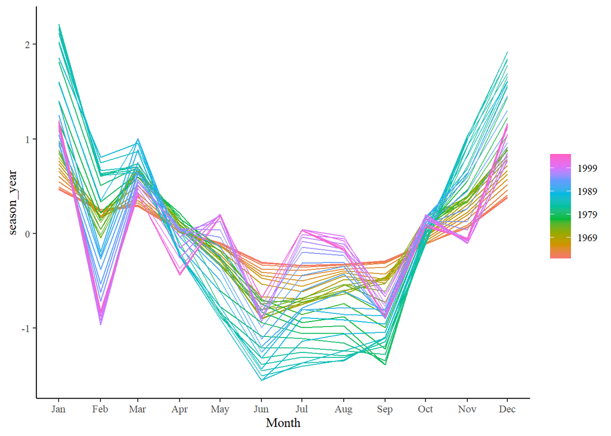

```
## Plot variable not specified, automatically selected `.vars = season_adjust`
```

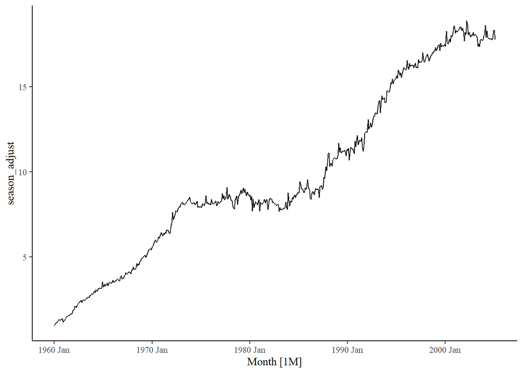

```r
canadian_gas %>%
  model(
    STL(Volume ~ trend(window = 18) +
                   season(window = 6),
    robust = TRUE)) %>%
  components() %>%
  select(Month, season_adjust) %>%
  autoplot()
```

It seems ok. I have tried to change the window settings, but they don’t seem to change the trend that drastically.

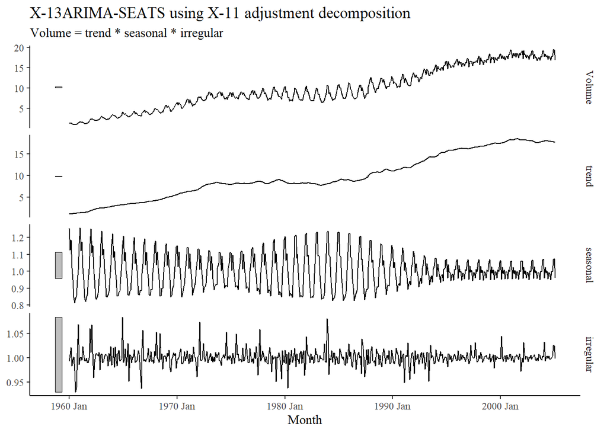

```r
canadian_gas %>%
  model(
    x11 = X_13ARIMA_SEATS(Volume ~ x11())
  ) %>%
  components() %>%
  autoplot()
```

Surprising. Here, seasonality is a lot higher in the sixties.

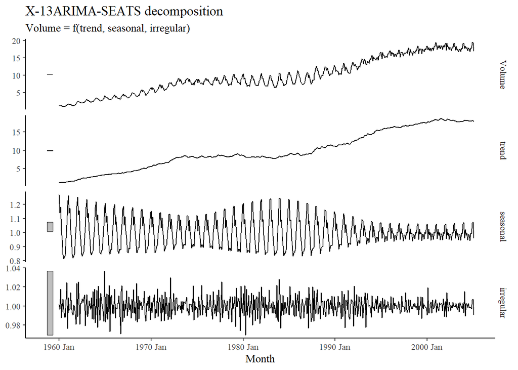

```r
canadian_gas %>%
  model(
    x11 = X_13ARIMA_SEATS(Volume ~ seats())
  ) %>%
  components() %>%
  autoplot()
```

x11 and SEATS are quite similar to my untrained eyes, to be fair. I guess there are some subtleties in each that make them more efficient in specific situations. For now, both seem good. See [Seasonal Adjustment Methods and Real Time Trend-cycle Estimation](https://www.amazon.fr/dp/3319318209?tag=otexts0e-21&geniuslink=true) for a discussion about it.

```r
canadian_gas %>%
  model(
    x11 = X_13ARIMA_SEATS(Volume ~ x11())
  ) %>%
  components() %>%
  select(Month, seasonal) %>%
  gg_season()
```

```
## Plot variable not specified, automatically selected `y = seasonal`
```

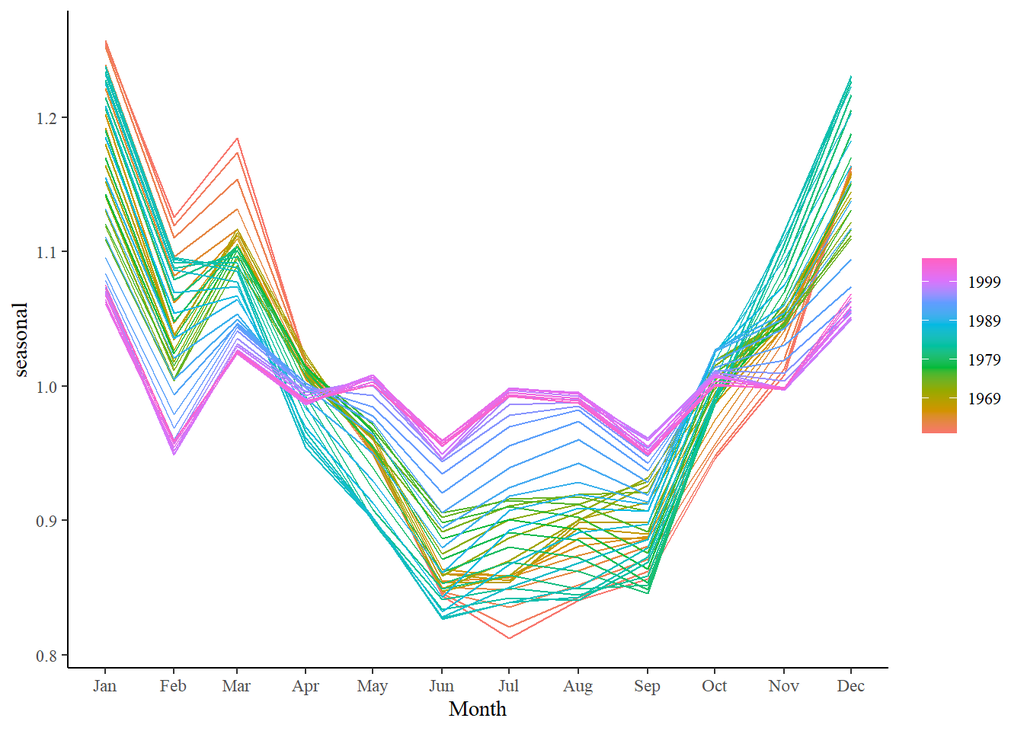

It’s funny to see the seasonality is quite different from the one obtained with STL.